# BIFX551 Midterm - Project 1

Mike Murphy

2024-03-12

# Conditions Contributing to COVID-19 Deaths, by State and Age, Provisional 2020-2023

## This dataset is interesting as it explores comorbidities with COVID-19 over three years.

```r
#Downloading the CSV dataset and creating the data object
#https://data.cdc.gov/NCHS/Conditions-Contributing-to-COVID-19-Deaths-by-Stat/hk9y-quqm/about_data
download.file(url = "https://data.cdc.gov/api/views/hk9y-quqm/rows.csv?accessType=DOWNLOAD", "covid.csv")
covid_data <- read.csv("covid.csv")
```

```r
#Loading packages
library("dplyr")
```

```r
library("ggplot2")
library(tidyr)
```

### Here we look at the summary of the dataset and remove N.A. values to make further analysis easier.

```r
#Viewing summary data
summary(covid_data)
```

```
##   Data.As.Of         Start.Date          End.Date            Group
##  Length:621000      Length:621000      Length:621000      Length:621000
##  Class :character   Class :character   Class :character   Class :character
##  Mode  :character   Mode  :character   Mode  :character   Mode  :character
##
##
##
##
##       Year           Month          State           Condition.Group
##  Min.   :2020    Min.   : 1.0    Length:621000      Length:621000
##  1st Qu.:2020    1st Qu.: 3.0    Class :character   Class :character
##  Median :2021    Median : 6.0    Mode  :character   Mode  :character
##  Mean   :2021    Mean   : 6.2
##  3rd Qu.:2022    3rd Qu.: 9.0
##  Max.   :2023    Max.   :12.0
##  NA's   :12420   NA's   :62100
##   Condition         ICD10_codes         Age.Group         COVID.19.Deaths
##  Length:621000      Length:621000      Length:621000      Min.   :      0.0
##  Class :character   Class :character   Class :character   1st Qu.:      0.0
##  Mode  :character   Mode  :character   Mode  :character   Median :      0.0
##                                                           Mean   :    120.1
##                                                           3rd Qu.:     18.0
##                                                           Max.   :1146242.0
##                                                           NA's   :183449
##  Number.of.Mentions      Flag
##  Min.   :      0.0   Length:621000
##  1st Qu.:      0.0   Class :character
##  Median :      0.0   Mode  :character
##  Mean   :    129.3
##  3rd Qu.:     19.0
##  Max.   :1146242.0
##  NA's   :177577
```

```r
#Viewing the structure of the dataset
str(covid_data)
```

```
## 'data.frame':    621000 obs. of  14 variables:
##  $ Data.As.Of        : chr  "09/24/2023" "09/24/2023" "09/24/2023" "09/24/2023" ...
##  $ Start.Date        : chr  "01/01/2020" "01/01/2020" "01/01/2020" "01/01/2020" ...
##  $ End.Date          : chr  "09/23/2023" "09/23/2023" "09/23/2023" "09/23/2023" ...
##  $ Group             : chr  "By Total" "By Total" "By Total" "By Total" ...
##  $ Year              : int  NA NA NA NA NA NA NA NA NA NA ...
##  $ Month             : int  NA NA NA NA NA NA NA NA NA NA ...
##  $ State             : chr  "United States" "United States" "United States" "United States" ...
##  $ Condition.Group   : chr  "Respiratory diseases" "Respiratory diseases" "Respiratory diseases" "Respiratory diseases" ...
##  $ Condition         : chr  "Influenza and pneumonia" "Influenza and pneumonia" "Influenza and pneumonia" "Influenza and pneumonia" ...
##  $ ICD10_codes       : chr  "J09-J18" "J09-J18" "J09-J18" "J09-J18" ...
##  $ Age.Group         : chr  "0-24" "25-34" "35-44" "45-54" ...
##  $ COVID.19.Deaths   : int  1569 5804 15080 37414 82668 129005 138503 121119 12 531174 ...
##  $ Number.of.Mentions: int  1647 6029 15699 38878 85708 133088 141868 123018 12 545947 ...
##  $ Flag              : chr  "" "" "" "" ...
```

```r
#Further exploring the variables
#Group variables
print(unique(covid_data$Group))
```

```
## [1] "By Total" "By Year"  "By Month"
```

```r
#Condition variables
print(unique(covid_data$Condition.Group))
```

```
##  [1] "Respiratory diseases"
##  [2] "Circulatory diseases"
##  [3] "Sepsis"
##  [4] "Malignant neoplasms"
##  [5] "Diabetes"
##  [6] "Obesity"
##  [7] "Alzheimer disease"
##  [8] "Vascular and unspecified dementia"
##  [9] "Renal failure"
## [10] "Intentional and unintentional injury, poisoning, and other adverse events"
## [11] "All other conditions and causes (residual)"
## [12] "COVID-19"
```

```r
#State variables
print(unique(covid_data$State))
```

```
##  [1] "United States"        "Alabama"              "Alaska"
##  [4] "Arizona"              "Arkansas"             "California"
##  [7] "Colorado"             "Connecticut"          "Delaware"
## [10] "District of Columbia" "Florida"              "Georgia"
## [13] "Hawaii"               "Idaho"                "Illinois"
## [16] "Indiana"              "Iowa"                 "Kansas"
## [19] "Kentucky"             "Louisiana"            "Maine"
## [22] "Maryland"             "Massachusetts"        "Michigan"
## [25] "Minnesota"            "Mississippi"          "Missouri"
## [28] "Montana"              "Nebraska"             "Nevada"
## [31] "New Hampshire"        "New Jersey"           "New Mexico"
## [34] "New York"             "New York City"        "North Carolina"
## [37] "North Dakota"         "Ohio"                 "Oklahoma"
## [40] "Oregon"               "Pennsylvania"         "Rhode Island"
## [43] "South Carolina"       "South Dakota"         "Tennessee"
## [46] "Texas"                "Utah"                 "Vermont"
## [49] "Virginia"             "Washington"           "West Virginia"
## [52] "Wisconsin"            "Wyoming"              "Puerto Rico"
```

```r
#Removing NA from the dataset for downstream analysis
covid_data = na.exclude(covid_data)
```

### Investigating “Condition” variables of age, condition, and state. We subset the initial dataset to smaller dataframes based on the variable of interest.

```r
#Group by age groups
deaths_by_age <- covid_data %>%
  group_by(Age.Group) %>%
  filter(Age.Group != "All Ages" & Age.Group != "Not stated") %>%
  summarise(total_deaths = sum(COVID.19.Deaths, na.rm = TRUE))

#Group by conditions
deaths_by_condition <- covid_data %>%
  group_by(Condition.Group) %>%
  summarise(total_deaths = sum(COVID.19.Deaths, na.rm = TRUE)) %>%
  filter(Condition.Group != "COVID-19")

#Group by state
deaths_by_state <- covid_data %>%
  group_by(State) %>%
  summarise(total_deaths = sum(COVID.19.Deaths, na.rm = TRUE)) %>%
  filter(State != "United States") #United States is listed as a state, filtering it to not skew the rest of the data
```

### Graphing the subsets of data to better visualize some of the data contained in these dataframes.

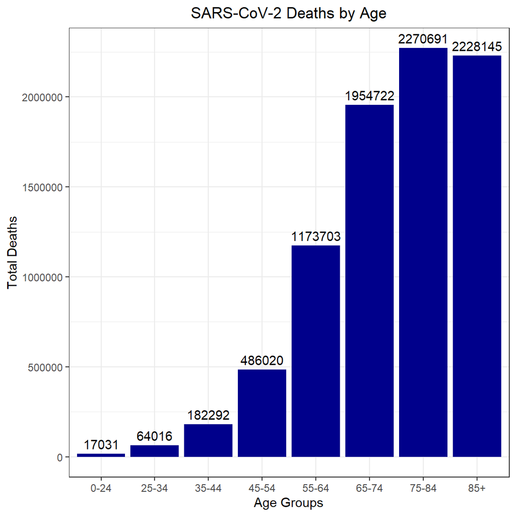

```r
#Graph for deaths by age group
ggplot(deaths_by_age, aes(x = `Age.Group`, y = `total_deaths`)) +
  geom_col(fill = "darkblue") +
  geom_text(aes(label = `total_deaths`), vjust = -0.5) +
  theme_bw() +
  xlab("Age Groups") +
  ylab("Total Deaths") +
  ggtitle("SARS-CoV-2 Deaths by Age") +
  theme(plot.title = element_text(hjust = 0.5)) #Centering the title
```

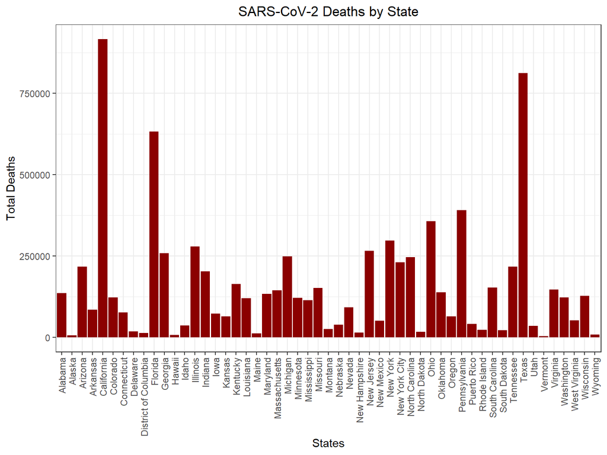

```r
ggplot(deaths_by_state, aes(x = `State`, y = `total_deaths`)) +
  geom_col(fill = "darkred") +
  theme_bw() +
  theme(axis.text.x = element_text(angle = 90, vjust = 0.5, hjust=1)) +  #Adjusted x-axis to better see the State names
  xlab("States") +
  ylab("Total Deaths") +
  ggtitle("SARS-CoV-2 Deaths by State") +
  theme(plot.title = element_text(hjust = 0.5)) #Centering the title
```

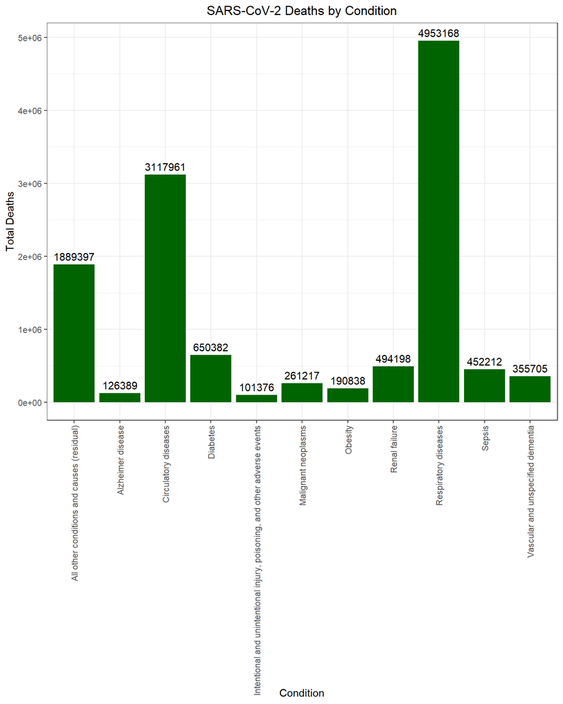

```r
ggplot(deaths_by_condition, aes(x = `Condition.Group`, y = `total_deaths`)) +
  geom_col(fill = "darkgreen") +
  geom_text(aes(label = `total_deaths`), vjust = -0.5) +
  theme_bw() +
  theme(axis.text.x = element_text(angle = 90, vjust = 0.5, hjust=1)) +  #Adjusted x-axis to better see the Condition names
  xlab("Condition") +
  ylab("Total Deaths") +
  ggtitle("SARS-CoV-2 Deaths by Condition") +
  theme(plot.title = element_text(hjust = 0.5)) #Centering the title
```

### Grouping the data by comorbidity (Alzheimer’s disease, renal failure, or sepsis) and by U.S. Region

#### Regions were identified based on this National Geographic map: https://education.nationalgeographic.org/resource/united-states-regions/

```r
#Group by state and by Alzheimers disease, renal failure, and sepsis
deaths_by_state_cond <- covid_data %>%
  group_by(State, Condition.Group) %>%
  summarise(total_deaths = sum(COVID.19.Deaths, na.rm = TRUE)) %>%
  filter(State != "United States") %>% #Filter out United States
  filter(Condition.Group %in% c("Alzheimer disease", "Renal failure", "Sepsis")) %>% #Looking into 3 conditions not commonly associated with SARS-CoV-2 death
  mutate(Region = case_when(State == "Washington"| State == "Oregon"| State == "California"| State == "Alaska"| State == "Idaho"
                            | State == "Montana"| State == "Wyoming"| State == "Utah"| State == "Colorado"
                            | State == "Nevada"| State == "Hawaii" ~ "West",

                            State == "Arizona"| State == "New Mexico"|State == "Oklahoma"| State == "Texas" ~ "Southwest",

                            State == "North Dakota"| State == "South Dakota"| State == "Nebraska"| State == "Kansas"| State == "Minnesota"|
                              State == "Iowa"| State == "Missouri"| State == "Wisconsin"| State == "Illinois"| State == "Michigan"|
                              State == "Indiana"| State == "Ohio" ~ "Midwest",

                            State == "Maine"| State == "Vermont"| State == "New Hampshire"| State == "Massachusetts"| State == "Connecticut"|
                              State == "Rhode Island"| State == "New York"| State == "New Jersey"| State == "Pennsylvania" ~ "Northeast",

                            State == "Delaware"| State == "Maryland"| State == "Virginia"| State == "West Virginia"| State == "North Carolina"|
                              State == "South Carolina"| State == "Kentucky"| State == "Tennessee"| State == "Georgia"| State == "Florida"|
                              State == "Alabama"| State == "Mississippi"| State == "Louisiana"| State == "Arkansas"  ~ "Southeast")) %>%
  na.exclude()
```

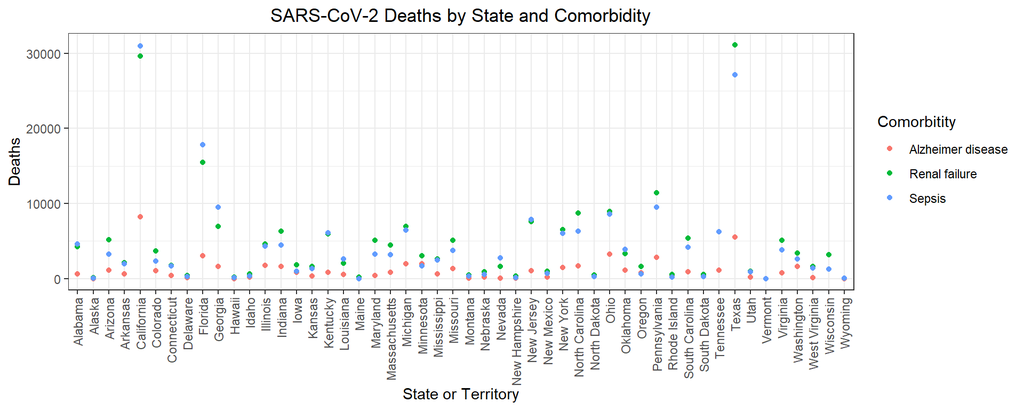

```r
ggplot(deaths_by_state_cond, aes(x = `State`, y = `total_deaths`, color = `Condition.Group`)) +
  geom_point()+
  theme_bw() +
  theme(axis.text.x = element_text(angle = 90, vjust = 0.5, hjust=1)) + #Adjusted x-axis to better see the State names
  xlab("State or Territory") +
  ylab("Deaths") +
  labs(color = "Comorbitity") +
  ggtitle("SARS-CoV-2 Deaths by State and Comorbidity") +
  theme(plot.title = element_text(hjust = 0.5)) #Centering the title
```

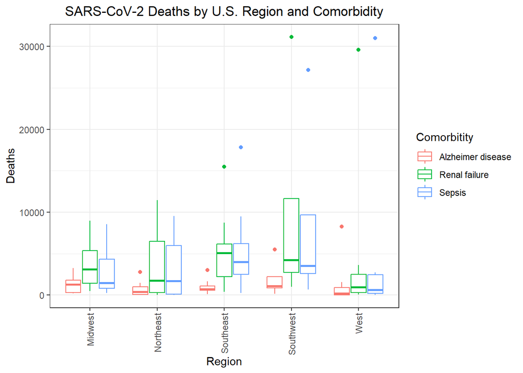

```r
ggplot(deaths_by_state_cond, aes(x = `Region`, y = `total_deaths`, color = `Condition.Group`)) +
  geom_boxplot()+
  theme_bw() +
  theme(axis.text.x = element_text(angle = 90, vjust = 0.5, hjust=1)) +
  xlab("Region") +
  ylab("Deaths") +
  labs(color = "Comorbitity") +
  ggtitle("SARS-CoV-2 Deaths by U.S. Region and Comorbidity") +
  theme(plot.title = element_text(hjust = 0.5)) #Centering the title
```

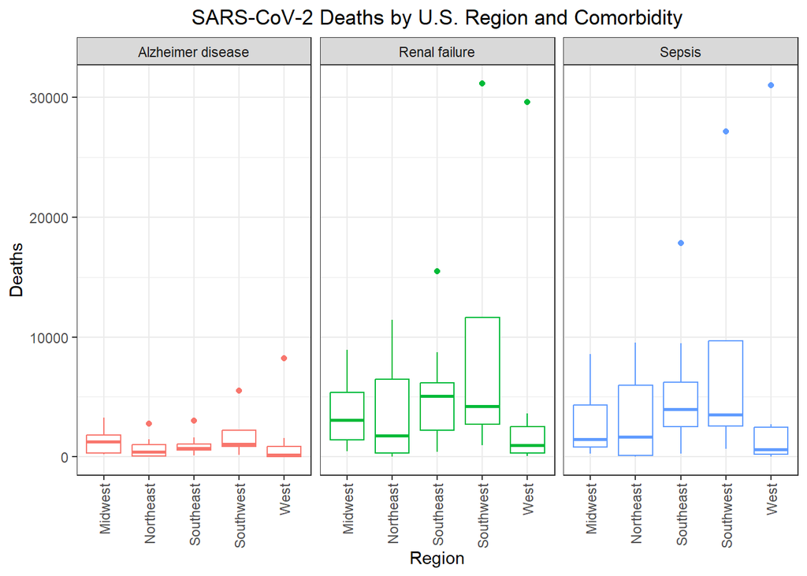

```r
ggplot(deaths_by_state_cond, aes(x = `Region`, y = `total_deaths`, color = `Condition.Group`)) +
  geom_boxplot()+
  theme_bw() +
  theme(axis.text.x = element_text(angle = 90, vjust = 0.5, hjust=1)) +
  xlab("Region") +
  ylab("Deaths") +
  labs(color = "Comorbitity") +
  ggtitle("SARS-CoV-2 Deaths by U.S. Region and Comorbidity") +
  theme(plot.title = element_text(hjust = 0.5)) + #Centering the title
  facet_wrap(vars(Condition.Group)) +
  theme(legend.position="none")
```

```r
#Group by state and by Alzheimers disease, renal failure, and sepsis
deaths_by_state_cond_time <- covid_data %>%
  group_by(State, Condition.Group, Year, Month) %>%
  summarise(total_deaths = sum(COVID.19.Deaths, na.rm = TRUE)) %>%
  filter(State != "United States") %>%
  filter(Condition.Group %in% c("Alzheimer disease", "Renal failure", "Sepsis")) %>% #Looking into 3 conditions not commonly associated with SARS-CoV-2 death
  mutate(Region = case_when(State == "Washington"| State == "Oregon"| State == "California"| State == "Alaska"| State == "Idaho"
                            | State == "Montana"| State == "Wyoming"| State == "Utah"| State == "Colorado"
                            | State == "Nevada"| State == "Hawaii" ~ "West",

                            State == "Arizona"| State == "New Mexico"|State == "Oklahoma"| State == "Texas" ~ "Southwest",

                            State == "North Dakota"| State == "South Dakota"| State == "Nebraska"| State == "Kansas"| State == "Minnesota"|
                              State == "Iowa"| State == "Missouri"| State == "Wisconsin"| State == "Illinois"| State == "Michigan"|
                              State == "Indiana"| State == "Ohio" ~ "Midwest",

                            State == "Maine"| State == "Vermont"| State == "New Hampshire"| State == "Massachusetts"| State == "Connecticut"|
                              State == "Rhode Island"| State == "New York"| State == "New Jersey"| State == "Pennsylvania" ~ "Northeast",

                            State == "Delaware"| State == "Maryland"| State == "Virginia"| State == "West Virginia"| State == "North Carolina"|
                              State == "South Carolina"| State == "Kentucky"| State == "Tennessee"| State == "Georgia"| State == "Florida"|
                              State == "Alabama"| State == "Mississippi"| State == "Louisiana"| State == "Arkansas"  ~ "Southeast")) %>%
  na.exclude()
```

### We perform three seperate ANOVAs to measure if there is signifcant difference in SARS-CoV-2 comorbidity with either Alzheimer’s disease, renal failure, or sepsis based on U.S. Region.

```r
deaths_region_cond <- deaths_by_state_cond %>%
  pivot_wider(names_from = Condition.Group, values_from = total_deaths)

#Alzheimers disease
summary(aov(`Alzheimer disease` ~ Region, deaths_region_cond))
```

```
##             Df   Sum Sq Mean Sq F value Pr(>F)
## Region       4  4686124 1171531   0.528  0.716
## Residuals   45 99848425 2218854
```

```r
#Renal failure
summary(aov(`Renal failure` ~ Region, deaths_region_cond))
```

```
##             Df    Sum Sq  Mean Sq F value Pr(>F)
## Region       4 1.531e+08 38284839   0.986  0.425
## Residuals   45 1.748e+09 38838318
```

```r
#Sepsis
summary(aov(Sepsis ~ Region, deaths_region_cond))
```

```
##             Df    Sum Sq  Mean Sq F value Pr(>F)
## Region       4 1.270e+08 31739232   0.826  0.516
## Residuals   45 1.729e+09 38432340
```

### Based on the p-values from the ANOVAS, there is no significant difference in SARS-CoV-2 comobidity with either Alheimer’s disease, renal failure, or sepsis based on U.S. Region.